# Final project: Stock Prediction

Given the recent stock market history, you will predict the return for ticker AAPL for the day ahead.

## Objectives

You will demonstrate your strengths in several areas, especially

- Exploratory Data Analysis
- Feature Engineering
- Creating, testing and evaluating models
- Error analysis and Prediction **using Neural Networks**.

Your objective will be to predict next period price returns of a stock given its past prices.

**To be precise**

- given recent prices for AAPL you will predict the next *return*
- *return* will be defined precisely below
- you will be evaluated on a holdout data directory
  - it will have 2 years of data
  - you will be required to predict next period returns for the final 200 days
  - when making a prediction for date $t$, where $t$ is in the holdout data range (**beyond** the last training date)
    - you may use *actual* holdout data for dates strictlty prior to date $t$
    - That is: your prediction for date $t$ *does not* need to be dependent on your *prediction* for date $(t-1)$

**Predicting forward returns/prices is hard ! If you could do it well: you would be rich**

Given that fact, out of sample performance will **not** be the sole metric for your grade

This project will test your ability to analyze data, create hypotheses, test them, and improve through iteration.

**You will learn a lot, especially from failures**

This project provides a wealth of opportunity for

- Exploratory data analysis
  - This can suggest several different approaches to building one or more models
- Error Analysis
- Creating, and evaluating models iteratively, learning from past failures and successes.

So your performance will be based on your creativity and experimental process, even if the process does not lead to great out of sample performance

## The data

As explained in the Final Project Overview:

- you will be given a data directory for training
  - supplied as a compressed archive file in the course's Resource tab in NYU Classes
  - unpacking this file will yield directory `./Data/train`

The data directory will contain one file per ticker, with a history going back many years of fields including

- Price: Close, Open, High, Low
- Volume

"return" means the percent change in the **Close** feature

You will need to

- decide which files and which fields to use
- prepare the data for training and testing
  - convert from price to return as necessary
  - prepare train and test examples:

## Data preparation

- The files contain prices; your goal is to predict a *return* not a price
- Your goal is to predict the **percent change of the Close feature** ("return")
- Your predicted return for day $t$ should be a function of data occuring *before* day $t$

So your first step will be to create a suitable training set.

For example, the following training set is a good starting point:

- each row is an example
- each row will have a column `Dt` indicating time $t$
- each example has *at least* 20 features
  - derived from AAPL features occuring *before* time $t$
- the target for the row with time $t$ should be the *return* of AAPL for date $t$
  - i.e., the percent price change of AAPL from time $t-1$ to time $t$

## Out of sample evaluation

*You* should test your models out of sample.

This will be beneficial as *we* will evaluate your model out of sample using a holdout data directory.

The *holdout data directory* will be for dates that are strictly later than the latest date in the training data directory.

- will contain 2 years of data
- you will be required to predict the latest 200 returns of AAPL for this holdout directory
- your submission *must work on the holdout directory*
  - you should assume the directory is at relative path `./data/holdout`

So you might want to create your own validation/test data (from the training data directory) that mimics what the holdout data directory will contain.

It is up to you to decide on the out of sample data that you use for model development.

## Suggestions for getting started

The problem we presented to you is unstructured and not precisely defined in full detail.

- Start by defining, in detail, the problem that you will attempt to solve
  - Do you view this as a Regression task ? A Classification task
  - Justify your choice ~ Define the Performance Metric that you think is appropriate
  - Justify your choice
- Start with a simple model, using only data from AAPL (few features)
  - Use the model to get a feel for the problem
  - Will be a good baseline
  - Will help you form new hypotheses to test
    - may guide the choice of additional features
- Create new models iteratively
  - Train and evaluate a "simpler" model
  - Evalute performance
  - Perform error analysis
  - Propose a new "less simple" model
    - add as many features as you like, from any file in the directory
- Be disciplined in your process: avoid repeating code
  - It will be easier if you have a single piece of code that works for
    - the training directory
    - the test directory (that you might choose to create)
    - the holdout directory
  - This will
    - simplify your process
    - help ensure that your submission will work on the holdout directory !

## Warning: Avoid looking into the future !

Obviously, you should not use knowledge of the future to predict future prices.

But it is surprisingly easy to inadvertantly do so ! For example:

- when standardizing a data set: you might compute averages and standard deviations over the full range of dates
  - this means that the earliest dates have implicit knowledge of later dates
    - for example, suppose the mean increases after 10 days
    - the observations of the first 9 days *should not know* that the mean of the entire data range is different than what is available from earlier observations

## Evaluating your model

Your goals

- demonstrate that your models can predict in-sample (based on training only) somewhat successfully
  - this is easier than predicting out of sample
  - this will show that your model has "learned" something
- evaluate your model out of sample using the validation/test set you created
- run multiple experiments to try to improve out of sample prediction
- present a "final model" which we will evaluate with a holdout dataset
  - The holdut dataset will be identical in structure to the full data set we provide
  - *BUT* the dates will be strictly after the dates in the full dataset.

## Final reminder: document your thought process

**The key to getting a good grade** is to

- document everything you do
- justify the many choices you will have to make -- use data and intuition to back up your statements
- report on failed theories/experiments
  - it shows the amount of effort you expended
  - tell us
    - why you thought it was a good idea to try
    - what you learned from the failure
    - how the failure led you to try something different

The out of sample prediction is hard -- you may or may not do well.

What is important is to see how you tried to improve and how failure as well as success led to better experiments.

# Get the data

```python
import os
import numpy as np
import pandas as pd
import matplotlib.pyplot as plt
import seaborn as sns
sns.set_style("whitegrid")

import sklearn
from sklearn.impute import SimpleImputer

import helper
helper = helper.Helper()

# Data directory
DATA_DIR = './Data/train/'
```

We will walk through the data directory to get all tickers.

```python
all_tickers = []
filenames = os.listdir(DATA_DIR)
for filename in filenames:
    all_tickers.append(filename.split('.')[0])

print(f'All tickers: {all_tickers}')
```

```
All tickers: ['AAPL', 'ACN', 'ADBE', 'CRM', 'CSCO', 'FB', 'GOOG', 'IBM', 'INTC', 'MA', 'MSFT', 'NVDA', 'SPY', 'V', 'XLB', 'XLE', 'XLF', 'XLI', 'XLK', 'XLP', 'XLRE', 'XLU', 'XLV', 'XLY']
```

## Load data and merge to a whole data frame

In this part, we handle the following tasks:

1. Read data from csv files.
2. Calculate the daily return for each ticker.
3. Calculate the roll factor=adj_close/close.
4. Calculate adjusted O/H/L prices using roll factor, adj_price=price * roll_factor.
5. Merge data to a single DataFrame.
6. Calculate the forwrad return, which is our target value.

```python
trade_ticker = 'AAPL'
trade_df = pd.read_csv(os.path.join(DATA_DIR, f'{trade_ticker}.csv')).set_index('Dt')
trade_df.index = pd.to_datetime(trade_df.index)
trade_df['Ret'] = trade_df['Adj Close'].pct_change(periods=1)
trade_df['Roll Factor'] = trade_df['Adj Close']/trade_df['Close']
trade_df['Adj Open'] = trade_df['Open'] * trade_df['Roll Factor']
trade_df['Adj High'] = trade_df['High'] * trade_df['Roll Factor']
trade_df['Adj Low'] = trade_df['Low'] * trade_df['Roll Factor']

all_df = trade_df.copy()

# merge DataFrame
for ticker in all_tickers:
    if ticker == trade_ticker:
        continue
    new_df = pd.read_csv(os.path.join(DATA_DIR, f'{ticker}.csv')).set_index('Dt')
    new_df.index = pd.to_datetime(new_df.index)
    new_df['Ret'] = new_df['Adj Close'].pct_change(periods=1)
    new_df['Roll Factor'] = new_df['Adj Close']/new_df['Close']
    new_df['Adj Open'] = new_df['Open'] * new_df['Roll Factor']
    new_df['Adj High'] = new_df['High'] * new_df['Roll Factor']
    new_df['Adj Low'] = new_df['Low'] * new_df['Roll Factor']

    all_df = all_df.join(new_df, how='left', rsuffix=f'_{ticker}')
all_df.columns = [col+'_AAPL' for col in all_df.columns[:13]] + list(all_df.columns[13:])
all_df['FwdRet_AAPL'] = all_df['Adj Close_AAPL'].pct_change(periods=1).shift(-1)

print(f'Data shape: {all_df.shape}')
```

```
Data shape: (4277, 313)
```

```python
all_base_features = ['Adj Close', 'Close', 'Div', 'Factor', 'High', 'Low', 'Open', 'Volume', 'Ret', 'Adj Open', 'Adj High', 'Adj Low']
```

## Have a look at the data

After combining all the historical data to a single dataframe, we have several findings:

1. Tickers such as FB and ACN have their **IPO dates after the first date**, making them lack of data for many days. How to **handle those NaN** data will become a key issue in the following research.
2. Close prices have their adjusted form, but other prices such as **O/H/L prices need to be adjusted** in order to be used to generate comparable features.
3. The tickers consists of **equity ticker and ETF tickers**. We might need to seperately model the data.

```python
all_df.head()
```

| Dt | Adj Close_AAPL | Close_AAPL | Div_AAPL | Factor_AAPL | High_AAPL | Low_AAPL | Open_AAPL | Volume_AAPL | Ret_AAPL | Roll Factor_AAPL | ... | High_XLY | Low_XLY | Open_XLY | Volume_XLY | Ret_XLY | Roll Factor_XLY | Adj Open_XLY | Adj High_XLY | Adj Low_XLY | FwdRet_AAPL |
| --- | --- | --- | --- | --- | --- | --- | --- | --- | --- | --- | --- | --- | --- | --- | --- | --- | --- | --- | --- | --- | --- |
| 2000-01-03 | 3.4785 | 111.938 | 0.0 | 1.0 | 112.500 | 101.688 | 104.8750 | 133949200.0 | NaN | 0.031075 | ... | 31.0000 | 29.8590 | 31.000 | 212900.0 | NaN | 0.783502 | 24.288564 | 24.288564 | 23.394588 | -0.084318 |
| 2000-01-04 | 3.1852 | 102.500 | 0.0 | 1.0 | 110.625 | 101.188 | 108.2500 | 128094400.0 | -0.084318 | 0.031075 | ... | 29.8130 | 29.0310 | 29.688 | 177200.0 | -0.030081 | 0.783497 | 23.260460 | 23.358397 | 22.745703 | 0.014630 |
| 2000-01-05 | 3.2318 | 104.000 | 0.0 | 1.0 | 110.563 | 103.000 | 103.7500 | 194580400.0 | 0.014630 | 0.031075 | ... | 29.3461 | 28.7190 | 29.344 | 124600.0 | -0.012301 | 0.783513 | 22.991404 | 22.993049 | 22.501708 | -0.086546 |
| 2000-01-06 | 2.9521 | 95.000 | 0.0 | 1.0 | 107.000 | 95.000 | 106.1183 | 191993200.0 | -0.086546 | 0.031075 | ... | 29.4060 | 28.9991 | 29.047 | 135800.0 | 0.011370 | 0.783490 | 22.758028 | 23.039301 | 22.720499 | 0.047390 |
| 2000-01-07 | 3.0920 | 99.500 | 0.0 | 1.0 | 101.000 | 95.500 | 96.5000 | 115183600.0 | 0.047390 | 0.031075 | ... | 30.5630 | 29.5000 | 29.500 | 70000.0 | 0.047108 | 0.783490 | 23.112950 | 23.945800 | 23.112950 | -0.017594 |

5 rows × 313 columns

## Description of attributes

From Yahoo Finance, we get the attributes of the given tickers. The attributes such as ticker type and sector provide information for further research:

1. To predict AAPL returns, we might **use more correlated firms from Techonology sector** such as ADBE and CSCO.
2. To predict AAPl return, we can **use the Technology index and XLK** to find de-noised trends in the sector.

```python
ticker_info = pd.DataFrame(
    {
        'AAPL': ['Apple Inc', 'Equity', 'Technology', 'Consumer Electronics'],
        'ACN': ['Accenture plc', 'Equity', 'Technology', 'Information Technology Services'],
        'ADBE': ['Adobe Inc', 'Equity', 'Technology', 'Software—Infrastructure'],
        'CRM': ['salesforce.com, inc', 'Equity', 'Technology', 'Software—Application'],
        'CSCO': ['Cisco Systems, Inc', 'Equity', 'Technology', 'Communication Equipment'],
        'FB': ['Facebook, Inc', 'Equity', 'Communication Services', 'Internet Content & Information'],
        'GOOG': ['Alphabet Inc', 'Equity', 'Communication Services', 'Internet Content & Information'],
        'IBM': ['International Business Machines Corporation', 'Equity', 'Technology', 'Information Technology Services'],
        'INTC': ['Intel Corporation', 'Equity', 'Technology', 'Semiconductors'],
        'MA': ['Mastercard Incorporated', 'Equity', 'Financial Services', 'Credit Services'],
        'MSFT': ['Microsoft Corporation', 'Equity', 'Technology', 'Software—Infrastructure'],
        'NVDA': ['NVIDIA Corporation', 'Equity', 'Technology', 'Semiconductors'],
        'SPY': ['SPDR S&P 500 ETF Trust', 'ETF', 'Large Blend', ''],
        'V': ['Visa Inc', 'Equity', 'Financial Services', 'Credit Services'],
        'XLB': ['Materials Select Sector SPDR Fund', 'ETF', 'Natural Resources', ''],
        'XLE': ['Energy Select Sector SPDR Fund', 'ETF', 'Equity Energy', ''],
        'XLF': ['Financial Select Sector SPDR Fund', 'ETF', 'Financial', ''],
        'XLI': ['Industrial Select Sector SPDR Fund', 'ETF', 'Industrials', ''],
        'XLK': ['Technology Select Sector SPDR Fund', 'ETF', 'Technology', ''],
        'XLP': ['Consumer Staples Select Sector SPDR Fund', 'ETF', 'Consumer Defensive', ''],
        'XLRE': ['The Real Estate Select Sector SPDR Fund', 'ETF', 'Real Estate', ''],
        'XLU': ['Utilities Select Sector SPDR Fund', 'ETF', 'Utilities', ''],
        'XLV': ['Health Care Select Sector SPDR Fund', 'ETF', 'Health', ''],
        'XLY': ['Consumer Discretionary Select Sector SPDR Fund', 'ETF', 'Consumer Cyclical', '']
    },
    index=['Name', 'Type', 'Sector', 'Industry']
).T

ticker_info
```

|  | Name | Type | Sector | Industry |
| --- | --- | --- | --- | --- |
| AAPL | Apple Inc | Equity | Technology | Consumer Electronics |
| ACN | Accenture plc | Equity | Technology | Information Technology Services |
| ADBE | Adobe Inc | Equity | Technology | Software—Infrastructure |
| CRM | salesforce.com, inc | Equity | Technology | Software—Application |
| CSCO | Cisco Systems, Inc | Equity | Technology | Communication Equipment |
| FB | Facebook, Inc | Equity | Communication Services | Internet Content & Information |
| GOOG | Alphabet Inc | Equity | Communication Services | Internet Content & Information |
| IBM | International Business Machines Corporation | Equity | Technology | Information Technology Services |
| INTC | Intel Corporation | Equity | Technology | Semiconductors |
| MA | Mastercard Incorporated | Equity | Financial Services | Credit Services |
| MSFT | Microsoft Corporation | Equity | Technology | Software—Infrastructure |
| NVDA | NVIDIA Corporation | Equity | Technology | Semiconductors |
| SPY | SPDR S&P 500 ETF Trust | ETF | Large Blend |  |
| V | Visa Inc | Equity | Financial Services | Credit Services |
| XLB | Materials Select Sector SPDR Fund | ETF | Natural Resources |  |
| XLE | Energy Select Sector SPDR Fund | ETF | Equity Energy |  |
| XLF | Financial Select Sector SPDR Fund | ETF | Financial |  |
| XLI | Industrial Select Sector SPDR Fund | ETF | Industrials |  |
| XLK | Technology Select Sector SPDR Fund | ETF | Technology |  |
| XLP | Consumer Staples Select Sector SPDR Fund | ETF | Consumer Defensive |  |
| XLRE | The Real Estate Select Sector SPDR Fund | ETF | Real Estate |  |
| XLU | Utilities Select Sector SPDR Fund | ETF | Utilities |  |
| XLV | Health Care Select Sector SPDR Fund | ETF | Health |  |
| XLY | Consumer Discretionary Select Sector SPDR Fund | ETF | Consumer Cyclical |  |

## Define performance measure

We consider this as a **Regression task** for the following reasons:

1. The goal of our model is to accurately predict the exact return so we can **build profitable trading strategies** based on the model.
2. Classification model only predicts the direction of the future return. However, the absolute value of the return or it strenghth is more important. Even we predict the direction of future return with 100% accuracy, if the return changes can not cover transaction costs, we will not be able to make profits with a perfect classification model. So for a common trading strategy which also considers the strategies combination, trading cost and portfolio optimization, the **classification couldn't provided sufficient information** and can only help to make naive long/short strategy.

Then we will use **R^2 or MSE** as Performance Metric for the following reasons:

1. R^2 and MSE measures how much variance of the future return we have explained. When R^2=1, it means we predict perfectly and can achieve the maximum profit possible. When we have no view of the return and only predict its mean=0, the R^2 becomes 0. When we are optimizing R^2, we are **directly optimzing the our risk-adjusted profits**.
2. R^2 and MSE uses squared errors. It means we are also **considering the risk averse** of a trader. If our prediction is very inaccurate, the prediction should be punished more for taking a large amount of risk with the power of 2.

## Train test split

We consider two ways of train test split for the given problem:

1. We can randomly shuffle the data and randomly split train/test sets. However, the given data sets are time series data, which means if we shuffle the data or use fractured time periods, the feature will be meaningless.
2. We can **leave the the data of latest days as test sets**. This will ensure the continiouty of the model and is very similar to situation where we will handle the holdout data.

```python
train_all_ratio = 0.8
train_ratio = 0.9

X, y = all_df.iloc[:,:-1].astype('float64'), all_df['FwdRet_AAPL'].astype('float64')
num_observations = X.shape[0]

X_train_all, X_test = X.iloc[: int(num_observations * train_all_ratio), :], X.iloc[int(num_observations * train_all_ratio):-1, :]
y_train_all, y_test = y.iloc[: int(num_observations * train_all_ratio)], y.iloc[int(num_observations * train_all_ratio):-1]


print(f'X shape: {X.shape}')
print(f'y shape: {y.shape}')
print(f'X_train_all shape: {X_train_all.shape}')
print(f'y_train_all shape: {y_train_all.shape}')
print(f'X_test shape: {X_test.shape}')
print(f'y_test shape: {y_test.shape}')
```

```
X shape: (4277, 312)
y shape: (4277,)
X_train_all shape: (3421, 312)
y_train_all shape: (3421,)
X_test shape: (855, 312)
y_test shape: (855,)
```

# Exploratory data analysis

## Check the distribution of target value

From the distribution figure, we have several findings:

1. The distribution **mean is positive, annully 31.87%**, so there should be a drift term in our future model.
2. The target value has a **very long left tail**. From some finance theories we learn that the abrupt crash might be predicted by the volatility of the market and volume. Therefore we will **introduce volatility related features**.

```
Annual return:   31.87%
Annual stdev:   46.31%
```

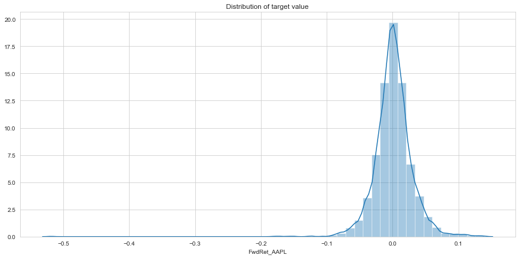

```python
plt.figure(figsize=(15,7))
sns.distplot(y_train_all)
plt.title('Distribution of target value')

print(f'Annual return: {y_train_all.mean()*252:8.2%}')
print(f'Annual stdev: {y_train_all.std()*16:8.2%}')
```

## Check the time-series trends of target value

Wit plotting the long run trends of the target values, we find that there exists apparent trends at different periods which gives us some hints:

1. We should **include trend features** in our features.
2. We might **incldue some seasonality features** in our features.

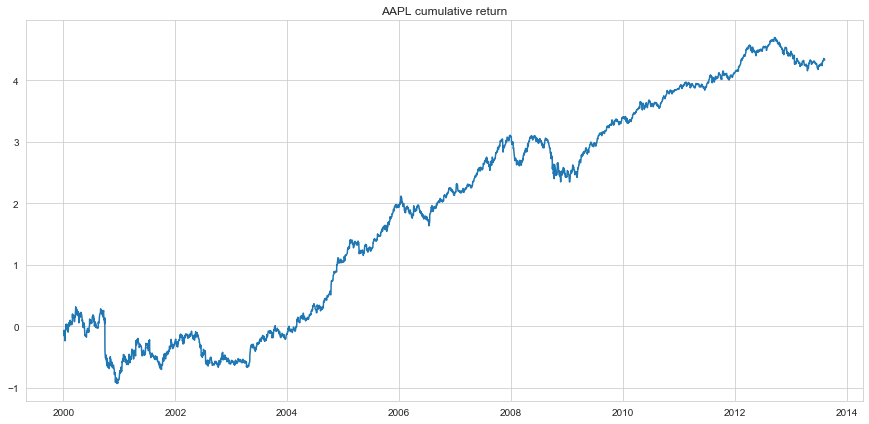

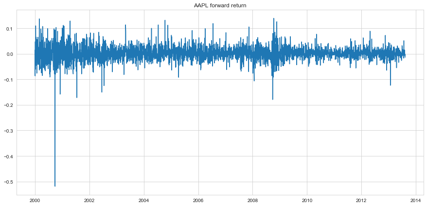

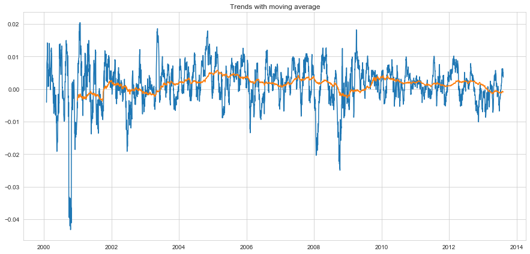

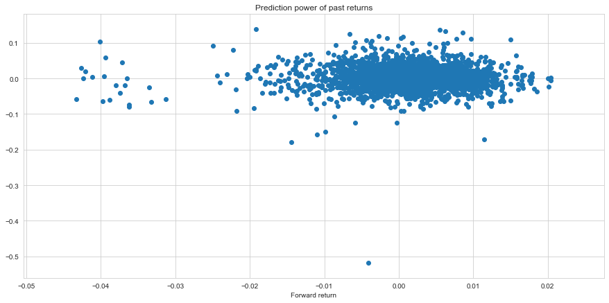

```python
plt.figure(figsize=(15,7))
plt.plot(y_train_all.cumsum())
plt.title('AAPL cumulative return')

plt.figure(figsize=(15,7))
plt.plot(y_train_all)
plt.title('AAPL forward return')

plt.figure(figsize=(15,7))
plt.plot(y_train_all.rolling(20).mean())
plt.plot(y_train_all.rolling(252).mean())
plt.title('Trends with moving average')

plt.figure(figsize=(15,7))
plt.scatter(X_train_all['Ret_AAPL'].rolling(20).mean(), y_train_all)
plt.xlabel('Past returns')
plt.xlabel('Forward return')
plt.title('Prediction power of past returns')
```

## Sparsity of historical data

Tickers such as FB, MA, V, XLRE shows large sparsity. We could **consider remove FB and XLRE**, and reduce the use of MA and V.

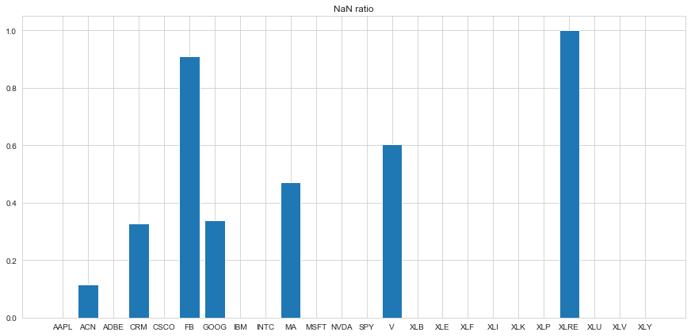

```python
nan_ratio = X_train_all[['Ret_'+ticker for ticker in all_tickers]].isna().sum()/X_train_all.shape[0]

plt.figure(figsize=(15,7))
plt.bar(all_tickers, nan_ratio.values)
plt.title('NaN ratio')
```

## Correlation matrix among different tickers

We have some observations from the correlation matrix (generated using last five years data):

1. FB has so few data (startin from 05-18-2012) that we should consider how to use this data.
2. XLRE has so few data (starting from 10-08-2015) and it is The Real Estate Select Sector SPDR Fund ETF Real Estate which should not be correlated with the AAPL. We could **remove XLRE** from the data.
3. Some high correlated returns are **XLK > SPY > XLY > GOOG > XLB > XLI > IBM > INTC > V**. Since the top three are all ETFs, we should pay more attention to how to properly transform ETF data to useful features.
4. Since many stocks are highly correlated especially for Technology sector, we can **use PCA to build our own sector index** which might be a de-noising method for the whole market trend.

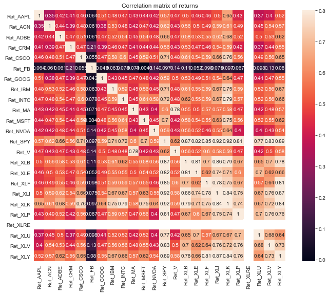

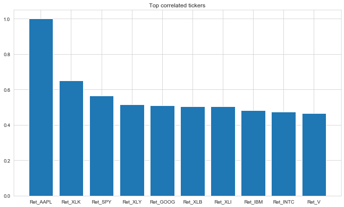

```python
ret_all_tickers = X_train_all[['Ret_'+ticker for ticker in all_tickers]].iloc[252*5:,]

corrmat = ret_all_tickers.corr()
f, ax = plt.subplots(figsize=(12, 9))
sns.heatmap(corrmat, vmax=.8, square=True, annot=True);
plt.title('Correlation matrix of returns')

plt.subplots(figsize=(12, 7))
top_ticker = corrmat['Ret_AAPL'].sort_values(ascending=False).iloc[:10]
plt.bar(top_ticker.index, top_ticker.values)
plt.title('Top correlated tickers')
```

## Market volatility and AAPL volatility

Some observations are:

1. AAPL's volatility is higher than SPY and they usually move together.
2. In the long run, the volatility is decreasing. So we should **remove the drift from volatility features**.
3. The market is very different in 2008 and 2009 compared with other years. So it might be helpful if we **give less weight to samples in 2008 and 2009**.

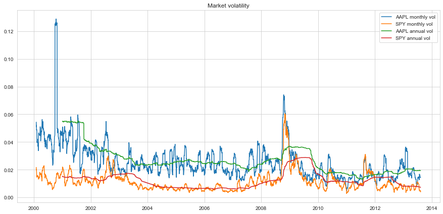

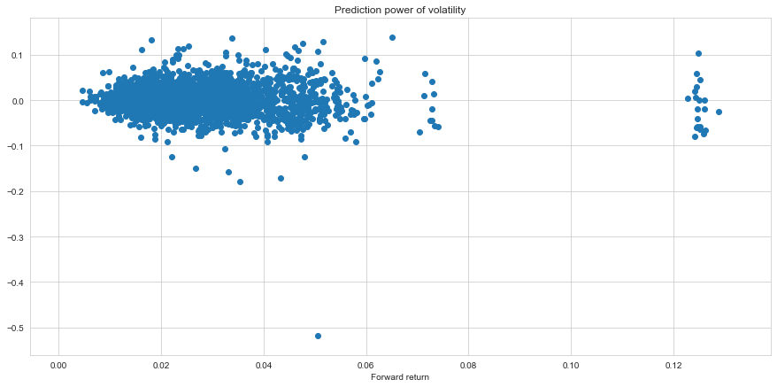

```python
plt.figure(figsize=(15,7))
plt.plot(X_train_all['Ret_AAPL'].rolling(20).std(), label='AAPL monthly vol')
plt.plot(X_train_all['Ret_SPY'].rolling(20).std(), label='SPY monthly vol')
plt.plot(X_train_all['Ret_AAPL'].rolling(252).std(), label='AAPL annual vol')
plt.plot(X_train_all['Ret_SPY'].rolling(252).std(), label='SPY annual vol')
plt.legend()
plt.title('Market volatility')

plt.figure(figsize=(15,7))
plt.scatter(X_train_all['Ret_AAPL'].rolling(20).std(), y_train_all)
plt.xlabel('Montly volatility')
plt.xlabel('Forward return')
plt.title('Prediction power of volatility')
```

## Volume as prediction

For volume data, we will need to use **log(volume) to improve stationary**. However the prediction power is still not obvious.

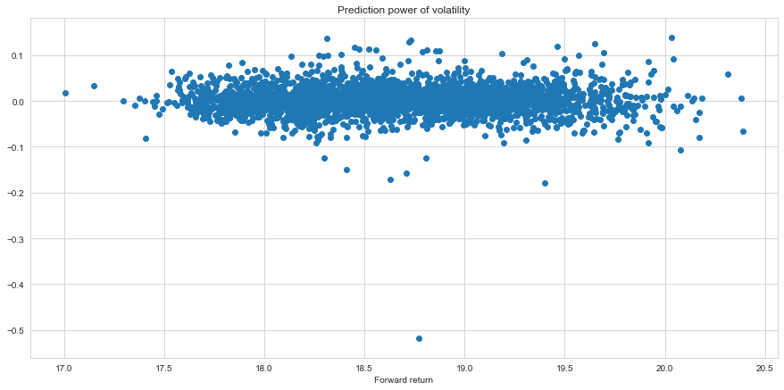

```python
plt.figure(figsize=(15,7))
plt.scatter(x=np.log(X_train_all['Volume_AAPL'].rolling(5).mean()), y=y_train_all)
plt.xlabel('Volume')
plt.xlabel('Forward return')
plt.title('Prediction power of volatility')
```

## Dividend and stock split events

Theoretically, dividends or stock split events might cause stock price to increase due to investors behaviors.

However after plotting the expected returns, we are surprised to find that **market treats the events as negative effects**. The futures return after a event happens is very negative.

```
Number of events: 7
```

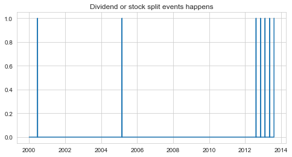

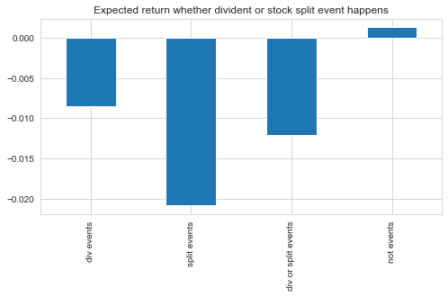

```python
div_event = X_train_all['Div_AAPL']>0
split_event = X_train_all['Factor_AAPL']>1
div_or_split_event = (X_train_all['Div_AAPL']>0) | (X_train_all['Factor_AAPL']>1)


plt.figure(figsize=(8, 4))
plt.plot(div_or_split_event)
plt.title('Dividend or stock split events happens')
print(f'Number of events: {div_or_split_event.sum()}')

plt.figure(figsize=(8, 4))
return_events = pd.Series([
    y_train_all[div_event>0].mean(),
    y_train_all[split_event>0].mean(),
    y_train_all[div_or_split_event>0].mean(),
    y_train_all[div_or_split_event==0].mean()
], index=['div events', 'split events', 'div or split events', 'not events'])

return_events.plot(kind='bar', title='Expected return whether divident or stock split event happens');
```

## January Effect

The **January Effect** is a perceived seasonal increase in stock prices during the month of January. Analysts generally attribute this rally to an increase in buying, which follows the drop in price that typically happens in December when investors, engaging in tax-loss harvesting to offset realized capital gains, prompt a sell-off.

It is obvious that **December shows less average return**.

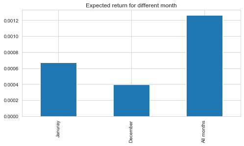

```python
trading_month = y_train_all.index.month

is_jan = trading_month == 1
is_dec = trading_month == 12

plt.figure(figsize=(8, 4))
return_events = pd.Series([
    y_train_all[is_jan>0].mean(),
    y_train_all[is_dec>0].mean(),
    y_train_all.mean(),
], index=['Januray', 'December', 'All months'])

return_events.plot(kind='bar', title='Expected return for different month')
```

## Sell in May effect

**Sell in May and go away** is a well-known financial-world adage. It is based on the historical underperformance of some stocks in the "summery" six-month period commencing in May and ending in October, compared to the "wintery" six-month period from November to April.

After analysis, we find that the **Sell in May Effect is stil valid** in our train data set.

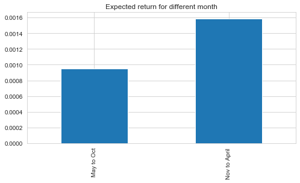

```python
sell_in_may = (trading_month >= 5) & (trading_month < 11)

plt.figure(figsize=(8, 4))
return_events = pd.Series([
    y_train_all[sell_in_may>0].mean(),
    y_train_all[sell_in_may==0].mean(),
], index=['May to Oct', 'Nov to April'])

return_events.plot(kind='bar', title='Expected return for different month')
```

# Prepare the data

## Cleaning

### Remove tickers that have large percentage of NaNs

Tickers such as FB, MA, V, XLRE shows large sparsity. We will remove **FB, XLRE and V**.

```
Ret_XLRE    1.000000
Ret_FB      0.910552
Ret_V       0.603332
Ret_MA      0.470038
Ret_GOOG    0.339959
Ret_CRM     0.328267
Ret_ACN     0.114002
Ret_XLY     0.000292
Ret_MSFT    0.000292
Ret_ADBE    0.000292
Ret_CSCO    0.000292
Ret_IBM     0.000292
Ret_INTC    0.000292
Ret_NVDA    0.000292
Ret_XLV     0.000292
Ret_SPY     0.000292
Ret_XLB     0.000292
Ret_XLE     0.000292
Ret_XLF     0.000292
Ret_XLI     0.000292
Ret_XLK     0.000292
Ret_XLP     0.000292
Ret_XLU     0.000292
Ret_AAPL    0.000292
dtype: float64
```

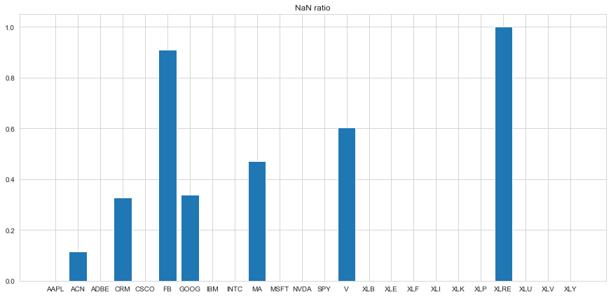

```python
# check sparsity of column data
nan_ratio = X_train_all[['Ret_'+ticker for ticker in all_tickers]].isna().sum()/X_train_all.shape[0]

plt.figure(figsize=(15,7))
plt.bar(all_tickers, nan_ratio.values)
plt.title('NaN ratio')
print(nan_ratio.sort_values(ascending=False))
```

```python
# remove sparse columns
remove_threshold = 0.5

nan_ratio = X_train_all.isna().sum()/X_train_all.shape[0]

remove_columns = X_train_all.columns[nan_ratio>remove_threshold]
print('Remove columns due to sparsity: {}'.format(remove_columns))

X_train_all = X_train_all.drop(columns=remove_columns)
X_test = X_test.drop(columns=remove_columns)
```

```
Remove columns due to sparsity: Index(['Adj Close_FB', 'Close_FB', 'Div_FB', 'Factor_FB', 'High_FB', 'Low_FB',
       'Open_FB', 'Volume_FB', 'Ret_FB', 'Roll Factor_FB', 'Adj Open_FB',
       'Adj High_FB', 'Adj Low_FB', 'Adj Close_V', 'Close_V', 'Div_V',
       'Factor_V', 'High_V', 'Low_V', 'Open_V', 'Volume_V', 'Ret_V',
       'Roll Factor_V', 'Adj Open_V', 'Adj High_V', 'Adj Low_V',
       'Adj Close_XLRE', 'Close_XLRE', 'Div_XLRE', 'Factor_XLRE', 'High_XLRE',
       'Low_XLRE', 'Open_XLRE', 'Volume_XLRE', 'Ret_XLRE', 'Roll Factor_XLRE',
       'Adj Open_XLRE', 'Adj High_XLRE', 'Adj Low_XLRE'],
      dtype='object')
```

Then we will only choose highly correlated tickers as feature source. Most of the are technology index, or SPY, or tech companies.

```python
# useful_tickers = [ticker for ticker in all_tickers if ticker not in ['FB', 'XLRE', 'V']]
useful_tickers = ['AAPL', 'XLK', 'SPY', 'XLY', 'GOOG', 'XLB', 'XLI']
print(useful_tickers)
```

```
['AAPL', 'XLK', 'SPY', 'XLY', 'GOOG', 'XLB', 'XLI']
```

### Remove rows that has large percentage of NaNs

```python
# check sparsity of row data and remove sparse rows
def check_sparsity_rows(df, remove_threshold=0.3):
    remove_row = list(df[df.isnull().mean(axis=1) > remove_threshold].index)
    keep_row = list(df[df.isnull().mean(axis=1) <= remove_threshold].index)

    print('Percent of Removed Rows: {}'.format(len(remove_row)/df.shape[0]))
    return keep_row

keep_row = check_sparsity_rows(X_train_all, remove_threshold=0.3)
X_train_all = X_train_all.loc[keep_row, :]
y_train_all = y_train_all.loc[keep_row]
print("X_train_all shape: ", X_train_all.shape)
print("y_train_all shape: ", y_train_all.shape)
```

```
Percent of Removed Rows: 0.0
X_train_all shape:  (3421, 273)
y_train_all shape:  (3421,)
```

### Imputation of missing values

We will use univariate imputation algorithms, which imputes values in the i-th feature dimension using only non-missing values in that feature dimension. Based on the properties of data, we seperately handle the imputation task.

1. **Imputation with mean value**: Volume. Since volume is highly correlated with volatility, it makes sense to use average volume to impute the NaNs.
2. **Imputation with first value**: Price related, (Adj) Close, (Adj) Open, (Adj) High, (Adj) Low, (Adj) Close. Since we will use price change and momentum indicators rather than price levels to predict returns, it makes sense to impute with first price and back fill the NaNs. It means we are assuming zero momentum before their first starting date and therefore it avoids look-ahead bias.
3. **Imputation with zeros**: Ret, Div. Before IPO, we assume that there are no dividend events and no price changes.
4. **Imputation with ones**: Factor. Before IPO, we assume that there are no stock split events.

```python
# imputation mean values
mean_univariate_columns = [col for col in X_train_all.columns if col.split('_')[0] in ['Volume']]
zero_univariate_columns = [col for col in X_train_all.columns if col.split('_')[0] in ['Ret', 'Div']]
one_univariate_columns = [col for col in X_train_all.columns if col.split('_')[0] in ['Factor', 'Roll Factor']]
first_univariate_columns = [col for col in X_train_all.columns if col.split('_')[0].split(' ')[0] in ['Adj', 'Open', 'High', 'Low', 'Close']]

# imputation with mean
imputer_uni_mean = SimpleImputer(missing_values=np.nan, strategy='mean')
X_train_all[mean_univariate_columns] = imputer_uni_mean.fit_transform(X_train_all[mean_univariate_columns])
X_test[mean_univariate_columns] = imputer_uni_mean.transform(X_test[mean_univariate_columns])

# imputation with zero
imputer_uni_zero = SimpleImputer(missing_values=np.nan, strategy='constant', fill_value=0)
X_train_all[zero_univariate_columns] = imputer_uni_zero.fit_transform(X_train_all[zero_univariate_columns])
X_test[zero_univariate_columns] = imputer_uni_zero.transform(X_test[zero_univariate_columns])

# imputation with one
imputer_uni_one = SimpleImputer(missing_values=np.nan, strategy='constant', fill_value=1)
X_train_all[one_univariate_columns] = imputer_uni_one.fit_transform(X_train_all[one_univariate_columns])
X_test[one_univariate_columns] = imputer_uni_one.transform(X_test[one_univariate_columns])

# imputation with first value
X_train_all[first_univariate_columns] = X_train_all[first_univariate_columns].fillna(method='bfill')

X_train_all
```

| Dt | Adj Close_AAPL | Close_AAPL | Div_AAPL | Factor_AAPL | High_AAPL | Low_AAPL | Open_AAPL | Volume_AAPL | Ret_AAPL | Roll Factor_AAPL | ... | Factor_XLY | High_XLY | Low_XLY | Open_XLY | Volume_XLY | Ret_XLY | Roll Factor_XLY | Adj Open_XLY | Adj High_XLY | Adj Low_XLY |
| --- | --- | --- | --- | --- | --- | --- | --- | --- | --- | --- | --- | --- | --- | --- | --- | --- | --- | --- | --- | --- | --- |
| 2000-01-03 | 3.4785 | 111.938 | 0.0000 | 1.0 | 112.500 | 101.6880 | 104.8750 | 133949200.0 | 0.000000 | 0.031075 | ... | 1.0 | 31.0000 | 29.8590 | 31.000 | 212900.0 | 0.000000 | 0.783502 | 24.288564 | 24.288564 | 23.394588 |
| 2000-01-04 | 3.1852 | 102.500 | 0.0000 | 1.0 | 110.625 | 101.1880 | 108.2500 | 128094400.0 | -0.084318 | 0.031075 | ... | 1.0 | 29.8130 | 29.0310 | 29.688 | 177200.0 | -0.030081 | 0.783497 | 23.260460 | 23.358397 | 22.745703 |
| 2000-01-05 | 3.2318 | 104.000 | 0.0000 | 1.0 | 110.563 | 103.0000 | 103.7500 | 194580400.0 | 0.014630 | 0.031075 | ... | 1.0 | 29.3461 | 28.7190 | 29.344 | 124600.0 | -0.012301 | 0.783513 | 22.991404 | 22.993049 | 22.501708 |
| 2000-01-06 | 2.9521 | 95.000 | 0.0000 | 1.0 | 107.000 | 95.0000 | 106.1183 | 191993200.0 | -0.086546 | 0.031075 | ... | 1.0 | 29.4060 | 28.9991 | 29.047 | 135800.0 | 0.011370 | 0.783490 | 22.758028 | 23.039301 | 22.720499 |
| 2000-01-07 | 3.0920 | 99.500 | 0.0000 | 1.0 | 101.000 | 95.5000 | 96.5000 | 115183600.0 | 0.047390 | 0.031075 | ... | 1.0 | 30.5630 | 29.5000 | 29.500 | 70000.0 | 0.047108 | 0.783490 | 23.112950 | 23.945800 | 23.112950 |
| ... | ... | ... | ... | ... | ... | ... | ... | ... | ... | ... | ... | ... | ... | ... | ... | ... | ... | ... | ... | ... | ... |
| 2013-08-02 | 58.7286 | 462.540 | 0.0000 | 1.0 | 462.850 | 456.6600 | 458.0100 | 68695900.0 | 0.012833 | 0.126970 | ... | 1.0 | 60.7500 | 60.1500 | 60.190 | 3737500.0 | 0.007133 | 0.915675 | 55.114492 | 55.627270 | 55.077865 |
| 2013-08-05 | 59.6059 | 469.450 | 0.0000 | 1.0 | 470.670 | 462.1167 | 464.6900 | 79713900.0 | 0.014938 | 0.126970 | ... | 1.0 | 60.6800 | 60.4540 | 60.610 | 1827300.0 | -0.002142 | 0.915674 | 55.499013 | 55.563111 | 55.356168 |
| 2013-08-06 | 59.0727 | 465.250 | 0.0000 | 1.0 | 471.890 | 462.1700 | 468.0200 | 83714400.0 | -0.008945 | 0.126970 | ... | 1.0 | 60.6100 | 59.9800 | 60.470 | 3169300.0 | -0.004126 | 0.915675 | 55.370838 | 55.499032 | 54.922157 |
| 2013-08-07 | 59.0384 | 464.980 | 0.0000 | 1.0 | 467.000 | 461.7700 | 463.7996 | 74714500.0 | -0.000581 | 0.126970 | ... | 1.0 | 60.1700 | 59.6500 | 60.020 | 3559300.0 | -0.008783 | 0.915675 | 54.958792 | 55.096143 | 54.619992 |
| 2013-08-08 | 58.9208 | 461.010 | 0.4357 | 1.0 | 464.100 | 457.9500 | 463.8550 | 63944300.0 | -0.001992 | 0.127808 | ... | 1.0 | 60.3800 | 59.8100 | 60.100 | 3020000.0 | 0.006688 | 0.915675 | 55.032076 | 55.288465 | 54.766530 |

3421 rows × 273 columns

### Check if NaNs correctly removed

```python
assert X_train_all.isna().sum().sum() == 0
assert X_test.isna().sum().sum() == 0

print(f'NaNs in X_train_all: {X_train_all.isna().sum().sum()}')
print(f'NaNs in X_test: {X_test.isna().sum().sum()}')
```

```
NaNs in X_train_all: 0
NaNs in X_test: 0
```

### Remove outliers

On September 29, 2000, Apple warned that its fourth-quarter profit would fall well short of Wall Street forecasts. The company blamed lower-than-expected sales in September, with particular weakness in the education market. Apple's market value was sliced in half Friday, its shares falling 27.75 to end the session 51.9 percent lower at 25.75.

We will see this event as outlier which is not likely happen in the future. We will do the following:

1. Remove the data on Sep 29, 2000.
2. Adjust the adjusted prices for the following days by multilying (1+outlier_ret) after Sep 28,2000.

```
X_train_all shape: (3420, 273)
y_train_all shape: (3420,)
```

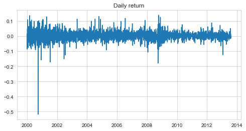

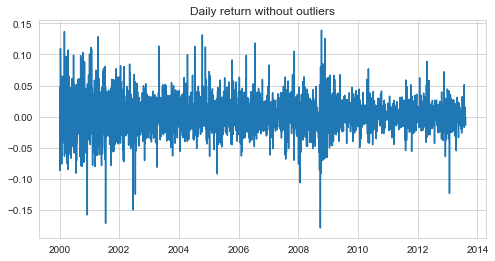

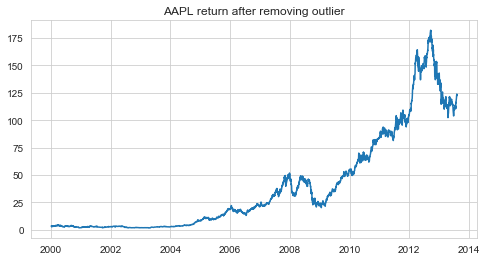

```python
plt.figure(figsize=(8,4))
plt.plot(y_train_all)
plt.title('Daily return')

outlier_ret = y_train_all['2000-9-28']

X_train_all = X_train_all.drop([pd.Timestamp('2000-09-28')], axis=0)
y_train_all = y_train_all.drop([pd.Timestamp('2000-09-28')])

# adjust the following days' adjusted prices
X_train_all.loc['2000-9-29':, ['Adj Open_AAPL', 'Adj High_AAPL', 'Adj Low_AAPL', 'Adj Close_AAPL']] = X_train_all.loc['2000-9-29':, ['Adj Open_AAPL', 'Adj High_AAPL', 'Adj Low_AAPL', 'Adj Close_AAPL']] / (1+outlier_ret)


plt.figure(figsize=(8,4))
plt.plot(y_train_all)
plt.title('Daily return without outliers')

plt.figure(figsize=(8,4))
plt.plot(X_train_all['Adj Close_AAPL'])
plt.title('AAPL return after removing outlier')


print(f'X_train_all shape: {X_train_all.shape}')
print(f'y_train_all shape: {y_train_all.shape}')
```

## Transformations and feature engineering

To generate time-series features, we have to **combine train/test sets X_all**.

```python
train_len = X_train_all.shape[0]

X_all = pd.concat([X_train_all, X_test])

print(f'X_all shape: {X_all.shape}')
```

```
X_all shape: (4275, 273)
```

```python
# AAPL features
AAPL_feature_columns = [col for col in X_all.columns if col.split('_')[1]=='AAPL']
print(AAPL_feature_columns)
```

```
['Adj Close_AAPL', 'Close_AAPL', 'Div_AAPL', 'Factor_AAPL', 'High_AAPL', 'Low_AAPL', 'Open_AAPL', 'Volume_AAPL', 'Ret_AAPL', 'Roll Factor_AAPL', 'Adj Open_AAPL', 'Adj High_AAPL', 'Adj Low_AAPL']
```

### Price levels features

```python
price_feature_columns = ['Adj Close_'+ticker for ticker in useful_tickers]
print(price_feature_columns)
```

```
['Adj Close_AAPL', 'Adj Close_XLK', 'Adj Close_SPY', 'Adj Close_XLY', 'Adj Close_GOOG', 'Adj Close_XLB', 'Adj Close_XLI']
```

### Past returns features

Past returns are the direct display of past price movements and returns for several days are linear combinationo of one-day return. Therefore we will only consider one-day return features.

```python
return_feature_columns = ['Ret_'+ticker for ticker in useful_tickers]
print(return_feature_columns)
```

```
['Ret_AAPL', 'Ret_XLK', 'Ret_SPY', 'Ret_XLY', 'Ret_GOOG', 'Ret_XLB', 'Ret_XLI']
```

### Techinical indicator and trends features

Some ML and DL models could learn the traditional indicators such as Moving Average Cross which is a linear combination of prices. Therefore to measure price trends, we will only add some non-linear indicators that might add value to our models:

1. RSI

RSI https://www.investopedia.com/terms/r/rsi.asp

1. OBV

OBV https://www.investopedia.com/terms/o/onbalancevolume.asp

```python
def RSI(price, window):
    change = price.diff(1).fillna(0)
    is_gain, is_loss = change > 0, change < 0
    gain, loss = change, -change
    gain[is_loss] = 0
    loss[is_gain] = 0
    rs = gain.ewm(span=window).mean().fillna(0) / loss.ewm(span=window).mean().fillna(0)
    rsi = (0.5 - (1 / (1 + rs))).fillna(0)
    return rsi

def OBV(price, volume, window):
    change = price.diff(1).fillna(0)
    return (np.sign(change) * volume).ewm(span=window).mean().fillna(0)
```

```
['RSI_7_AAPL', 'RSI_14_AAPL', 'RSI_28_AAPL', 'RSI_7_XLK', 'RSI_14_XLK', 'RSI_28_XLK', 'RSI_7_SPY', 'RSI_14_SPY', 'RSI_28_SPY', 'RSI_7_XLY', 'RSI_14_XLY', 'RSI_28_XLY', 'RSI_7_GOOG', 'RSI_14_GOOG', 'RSI_28_GOOG', 'RSI_7_XLB', 'RSI_14_XLB', 'RSI_28_XLB', 'RSI_7_XLI', 'RSI_14_XLI', 'RSI_28_XLI', 'OBV_7…
```

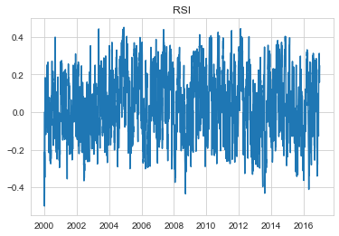

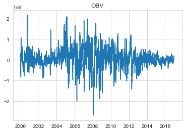

```python
for ticker in useful_tickers:
    for window in [7, 14, 28]:
        X_all[f'RSI_{window}_{ticker}'] = RSI(X_all['Adj Close_'+ticker], window)
        X_all[f'OBV_{window}_{ticker}'] = OBV(X_all['Adj Close_'+ticker], X_all['Volume_'+ticker], window)

plt.figure()
plt.plot(X_all['RSI_14_AAPL'])
plt.title('RSI')

plt.figure()
plt.plot(X_all['OBV_14_AAPL'])
plt.title('OBV')

trend_feature_columns = ([f'RSI_{window}_{ticker}' for ticker in useful_tickers for window in [7, 14, 28]]
                        + [f'OBV_{window}_{ticker}' for ticker in useful_tickers for window in [7, 14, 28]])
print(trend_feature_columns)
```

### Volume features

We will use log(volume) to improve stationary.

```python
for ticker in useful_tickers:
    X_all['log(Volume)_'+ticker] = np.log(X_all['Volume_'+ticker])

volume_feature_columns = ['log(Volume)_'+ticker for ticker in useful_tickers]
print(volume_feature_columns)
```

```
['log(Volume)_AAPL', 'log(Volume)_XLK', 'log(Volume)_SPY', 'log(Volume)_XLY', 'log(Volume)_GOOG', 'log(Volume)_XLB', 'log(Volume)_XLI']
```

### January effect features

```python
trading_month = X_all.index.month

X_all['is_January'] = trading_month == 1
X_all['is_December'] = trading_month == 12

jan_effect_feature_columns = ['is_January', 'is_December']
print(jan_effect_feature_columns)
```

```
['is_January', 'is_December']
```

### Dividend and stock split events features

```python
div_event = X_all['Div_AAPL']>0
split_event = X_all['Factor_AAPL']>1

X_all['is_div'] = X_all['Div_AAPL']>0
X_all['is_split'] = X_all['Factor_AAPL']>1

div_split_event_feature_columns = ['is_div', 'is_split']
print(div_split_event_feature_columns)
```

```
['is_div', 'is_split']
```

### Sell in May effect features

From EDA, we have found the Sell in May Effect is stil valid in our train data set.

```python
sell_in_may = (trading_month >= 5) & (trading_month < 11)

X_all['is_May_to_Oct'] = (trading_month >= 5) & (trading_month < 11)

sell_in_may_feature_columns = ['is_May_to_Oct']
print(sell_in_may_feature_columns)
```

```
['is_May_to_Oct']
```

### Volatility and range features

```python
for ticker in useful_tickers:
    for window in [20, 60, 250]:
        X_all[f'Vol_{window}_{ticker}'] = X_all['Ret_'+ticker].rolling(window).std().fillna(0)
        X_all[f'Range_{window}_{ticker}'] = ((X_all['Adj High_'+ticker] - X_all['Adj Low_'+ticker])/X_all['Adj Close_'+ticker]).rolling(window).mean().fillna(0)

vol_feature_columns = ([f'Vol_{window}_{ticker}' for ticker in useful_tickers for window in [20, 60, 250]]
                        + [f'Range_{window}_{ticker}' for ticker in useful_tickers for window in [20, 60, 250]])
print(vol_feature_columns)
```

```
['Vol_20_AAPL', 'Vol_60_AAPL', 'Vol_250_AAPL', 'Vol_20_XLK', 'Vol_60_XLK', 'Vol_250_XLK', 'Vol_20_SPY', 'Vol_60_SPY', 'Vol_250_SPY', 'Vol_20_XLY', 'Vol_60_XLY', 'Vol_250_XLY', 'Vol_20_GOOG', 'Vol_60_GOOG', 'Vol_250_GOOG', 'Vol_20_XLB', 'Vol_60_XLB', 'Vol_250_XLB', 'Vol_20_XLI', 'Vol_60_XLI', 'Vol_25…
```

### PCA to build index features

Using PCA on tickers' returns, we are actually building index of the market. It is useful because the index always shows more trend than individual stocks, which makes index easier to predict. After predicting index returns, we can use CAPM models to predict stock returns.

```
5 has a cumulative explained variane of: 0.9800986741951825
```

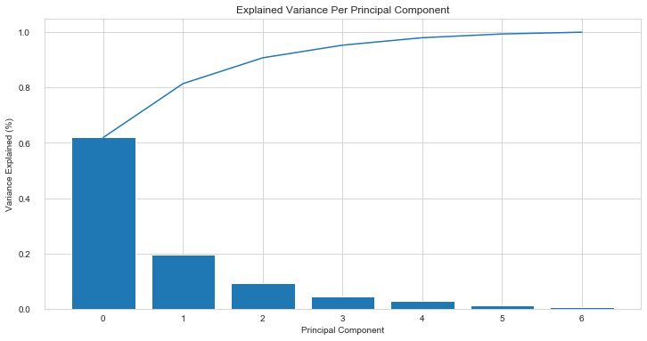

```python
from sklearn.decomposition import PCA

def scree_plot(pca_estimator):

    num_components = len(pca_estimator.explained_variance_ratio_)
    ind = np.arange(num_components)
    vals = pca_estimator.explained_variance_ratio_

    plt.figure(figsize=(12, 6))
    ax = plt.subplot(111)
    cumvals = np.cumsum(vals)
    ax.bar(ind, vals)
    ax.plot(ind, cumvals)

    ax.xaxis.set_tick_params(width=0)
    ax.yaxis.set_tick_params(width=2, length=12)

    ax.set_xlabel("Principal Component")
    ax.set_ylabel("Variance Explained (%)")
    plt.title('Explained Variance Per Principal Component')

pca = PCA(n_components = .999)
X_train_return_pca = pca.fit_transform(X_train_all[return_feature_columns])
X_test_return_pca = pca.transform(X_test[return_feature_columns])

scree_plot(pca)

n_components = 5
print(f'{n_components} has a cumulative explained variane of: {sum(pca.explained_variance_ratio_[:n_components])}')
```

The plots above show that the explained variance plateaus a couple of times. The first and sharpest drop-off is around 1 component.

Then we will have a look at the components for each principle component.

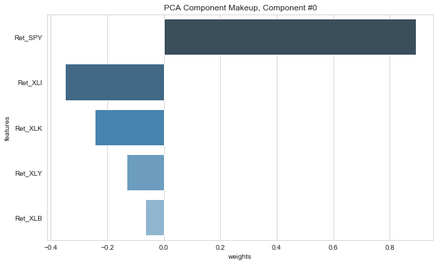

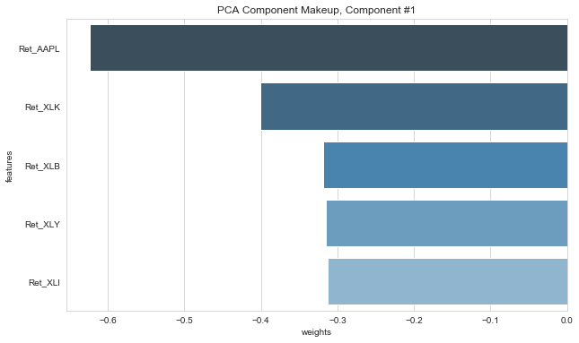

```python
def display_component(v, features_list, component_num, n_weights=10):

    # get index of component (last row - component_num)
    row_idx = component_num - 1

    # get the list of weights from a row in v, dataframe
    v_1_row = v[row_idx]
    v_1 = np.squeeze(v_1_row)

    # match weights to features in counties_scaled dataframe, using list comporehension
    comps = pd.DataFrame(list(zip(v_1, features_list)),
                         columns=['weights', 'features'])

    # we'll want to sort by the largest n_weights
    # weights can be neg/pos and we'll sort by magnitude
    comps['abs_weights']=comps['weights'].apply(lambda x: np.abs(x))
    sorted_weight_data = comps.sort_values('abs_weights', ascending=False).head(n_weights)

    # display using seaborn
    ax=plt.subplots(figsize=(10,6))
    ax=sns.barplot(data=sorted_weight_data,
                   x="weights",
                   y="features",
                   palette="Blues_d")
    ax.set_title("PCA Component Makeup, Component #" + str(component_num))
    plt.show()

for num in range (0,2):
    display_component(pca.components_, return_feature_columns, component_num=num, n_weights=5)
```

**Conclusion**

The conclusion makes sense because we know from CAPM model that the large variance of AAPL returns should be explained by the market returns.

### Check if NaNs in features

```python
assert X_all.isna().sum().sum()==0
print(f'NaNs in X_all: {X_all.isna().sum().sum()}')
```

```
NaNs in X_all: 0
```

## Train test split after feature engineering

```python
train_all_ratio = 0.8
train_ratio = 0.9

num_train = int(X_train_all.shape[0] * train_ratio)

X_train_all, X_test = X_all.iloc[:train_len, :], X_all.iloc[train_len:, :]
X_train, X_valid = X_train_all.iloc[:num_train, :], X_train_all.iloc[num_train:, :]
y_train, y_valid = y_train_all.iloc[:num_train], y_train_all.iloc[num_train:]


print(f'X_train_all shape: {X_train_all.shape}')
print(f'X_train shape: {X_train.shape}')
print(f'X_valid shape: {X_valid.shape}')
print(f'X_test shape: {X_test.shape}')

print(f'y_train shape: {y_train.shape}')
print(f'y_valid shape: {y_valid.shape}')
```

```
X_train_all shape: (3420, 369)
X_train shape: (3078, 369)
X_valid shape: (342, 369)
X_test shape: (855, 369)
y_train shape: (3078,)
y_valid shape: (342,)
```

## Scaling

```python
from sklearn.preprocessing import StandardScaler, RobustScaler

scaler = StandardScaler()
X_train_all_scale = pd.DataFrame(scaler.fit_transform(X_train_all), columns=X_train_all.columns)
X_test_scale = pd.DataFrame(scaler.transform(X_test), columns=X_test.columns)
```

# Model training

```python
import graphviz  ## need install
from sklearn import tree
from sklearn.pipeline import Pipeline

from sklearn.linear_model import LinearRegression, Ridge, Lasso
from sklearn.tree import DecisionTreeRegressor
from sklearn.ensemble import RandomForestRegressor

from sklearn.metrics import r2_score, mean_squared_error
from sklearn.model_selection import cross_val_score

import tensorflow as tf
from tensorflow import keras
from tensorflow.keras.models import Model, Sequential
from tensorflow.keras import layers
from tensorflow.keras.utils import plot_model
from tensorflow.keras import regularizers

from numpy.random import seed
seed(1)
tf.random.set_seed(2)


cross_validation_k = 5
```

```python
def test_sklearn_model(X_train_all, X_test, y_train_all, y_test, test_pipelilne, name, cv=False):

    test_pipelilne.fit(X_train_all, y_train_all)
    y_train_predict = test_pipelilne.predict(X_train_all)

    r2_is = r2_score(y_train_all, y_train_predict)
    MSE_is = mean_squared_error(y_train_all, y_train_predict)

    print("Model: {n:s}, in-sample R^2: {r:3.4%}, MSE: {m:3.4%}".format(n=name, r=r2_is, m=MSE_is))

    if cv:
        cross_val_scores = cross_val_score(test_pipelilne, X_train_all, y_train_all, scoring='neg_mean_squared_error', cv=cross_validation_k)
        print("Model: {n:s} average cross validation negative MSE={m:3.2%}".format(n=name, m=cross_val_scores.mean()))

    y_test_predict = test_pipelilne.predict(X_test)
    r2_oos = r2_score(y_test, y_test_predict)
    MSE_oos = mean_squared_error(y_test, y_test_predict)

    print("Model: {n:s}, out-of-sample R^2: {r:3.4%}, MSE: {m:3.4%}".format(n=name, r=r2_oos, m=MSE_oos))

    return test_pipelilne
```

## Baseline model: All zero

```python
print('Test MSE: {m:3.4%}'.format(m=mean_squared_error(y_test, np.zeros(y_test.shape))))
```

```
Test MSE: 0.0230%
```

## Baseline model: Lasso regression

Firstly, we will apply linear models. Since we are dealing with many highly correlated features, it is better to use Lasso regression because it has feature selection functions.

After model training, we find that the using **Return + Volume** improve the MSE to 0.0229%.

```
1. Features: AAPL
Model: Linear regression, in-sample R^2: 0.1341%, MSE: 0.0758%
Model: Linear regression average cross validation negative MSE=-0.08%
Model: Linear regression, out-of-sample R^2: -37.1265%, MSE: 0.0314%
Model parameters:
Intercept: 0.00142
---------------------------------------------
2. Features: Return
Model: Linear regression, in-sample R^2: 0.6563%, MSE: 0.0754%
Model: Linear regression average cross validation negative MSE=-0.08%
Model: Linear regression, out-of-sample R^2: -0.0442%, MSE: 0.0229%
Model parameters:
Intercept: 0.00142
---------------------------------------------
3. Features: Return + Volume
Model: Linear regression, in-sample R^2: 0.7653%, MSE: 0.0753%
```

```
Model: Linear regression average cross validation negative MSE=-0.08%
Model: Linear regression, out-of-sample R^2: 0.0773%, MSE: 0.0229%
Model parameters:
Intercept: 0.00142
---------------------------------------------
4. Features: Return + Volume + Price
Model: Linear regression, in-sample R^2: 0.9066%, MSE: 0.0752%
Model: Linear regression average cross validation negative MSE=-0.08%
Model: Linear regression, out-of-sample R^2: -1.2084%, MSE: 0.0232%
Model parameters:
Intercept: 0.00142
---------------------------------------------
5. Features: Sell in May + January effect + Dividend event
Model: Linear regression, in-sample R^2: 0.0985%, MSE: 0.0758%
Model: Linear regression average cross validation negative MSE=-0.08%
Model: Linear regression, out-of-sample R^2: -0.5991%, MSE: 0.0231%
Model parameters:
Intercept: 0.00142
---------------------------------------------
6. Features: Return + Volume + Sell in May + January effect + Dividend event
Model: Linear regression, in-sample R^2: 0.8644%, MSE: 0.0752%
Model: Linear regression average cross validation negative MSE=-0.08%
Model: Linear regression, out-of-sample R^2: -0.6718%, MSE: 0.0231%
Model parameters:
Intercept: 0.00142
---------------------------------------------
```

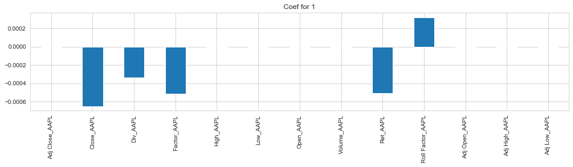

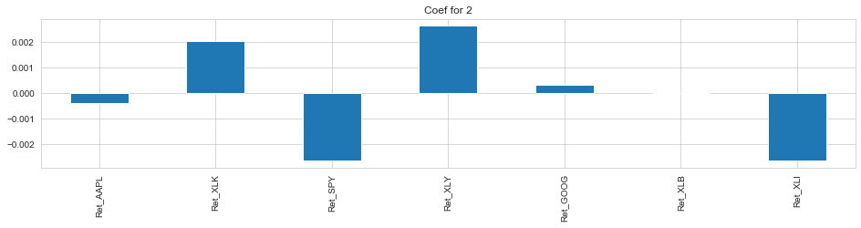

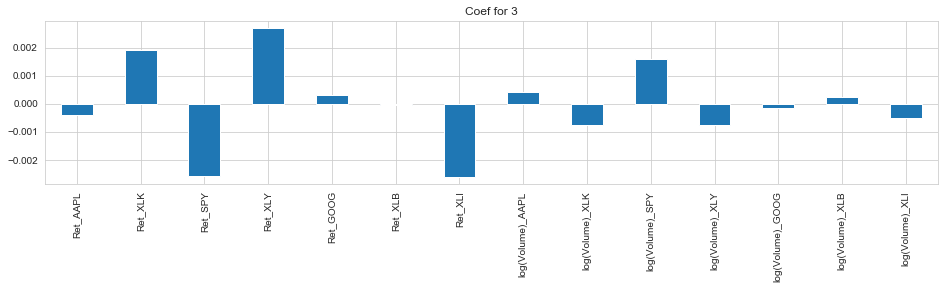

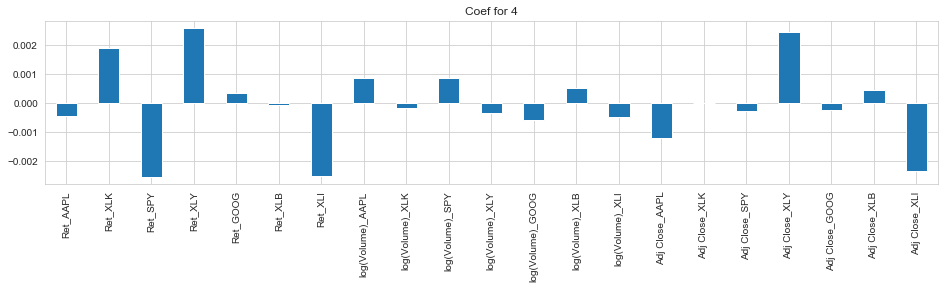

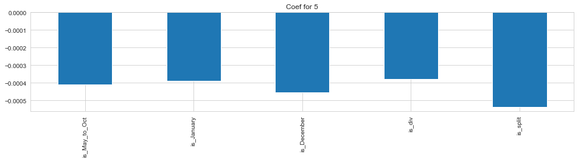

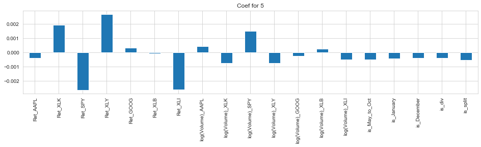

```python
def lr_show_parameters(test_pipeline, title):
    print('Model parameters:')
    print(f"Intercept: {pipeline_lr['model'].intercept_:.5f}")
    plt.figure(figsize=(16,3))
    pd.Series(pipeline_lr['model'].coef_, index=used_features).plot(kind='bar')
    plt.title(title)
    print('---------------------------------------------')


name = 'Linear regression'

regressor = Lasso(alpha=0.00001)
pipeline_lr = Pipeline([
    ("scaler", scaler),
    ("model", regressor)
])

print('1. Features: AAPL')
used_features = AAPL_feature_columns
pipeline_lr = test_sklearn_model(X_train_all[used_features], X_test[used_features], y_train_all, y_test, pipeline_lr, name, cv=True)
lr_show_parameters(pipeline_lr, 'Coef for 1')

print('2. Features: Return')
used_features = return_feature_columns
pipeline_lr = test_sklearn_model(X_train_all[used_features], X_test[used_features], y_train_all, y_test, pipeline_lr, name, cv=True)
lr_show_parameters(pipeline_lr, 'Coef for 2')

print('3. Features: Return + Volume')
used_features = return_feature_columns + volume_feature_columns
pipeline_lr = test_sklearn_model(X_train_all[used_features], X_test[used_features], y_train_all, y_test, pipeline_lr, name, cv=True)
lr_show_parameters(pipeline_lr, 'Coef for 3')

print('4. Features: Return + Volume + Price')
used_features = return_feature_columns + volume_feature_columns + price_feature_columns
pipeline_lr = test_sklearn_model(X_train_all[used_features], X_test[used_features], y_train_all, y_test, pipeline_lr, name, cv=True)
lr_show_parameters(pipeline_lr, 'Coef for 4')

print('5. Features: Sell in May + January effect + Dividend event')
used_features = sell_in_may_feature_columns + jan_effect_feature_columns + div_split_event_feature_columns
pipeline_lr = test_sklearn_model(X_train_all[used_features], X_test[used_features], y_train_all, y_test, pipeline_lr, name, cv=True)
lr_show_parameters(pipeline_lr, 'Coef for 5')

print('6. Features: Return + Volume + Sell in May + January effect + Dividend event')
used_features = return_feature_columns + volume_feature_columns + sell_in_may_feature_columns + jan_effect_feature_columns + div_split_event_feature_columns
pipeline_lr = test_sklearn_model(X_train_all[used_features], X_test[used_features], y_train_all, y_test, pipeline_lr, name, cv=True)
lr_show_parameters(pipeline_lr, 'Coef for 5')
```

```python
pipeline_lr['model'].coef_
```

```
array([-3.96041275e-04,  1.93678262e-03, -2.62010907e-03,  2.68381515e-03,
        3.22258440e-04, -4.46160443e-05, -2.61645194e-03,  4.25137260e-04,
       -7.47655520e-04,  1.52486241e-03, -7.50128100e-04, -2.34087587e-04,
        2.42679271e-04, -4.98030728e-04, -4.95495374e-04, -4.05551120e-04,
       -3.93486690e-04, -3.97950397e-04, -5.16916158e-04])
```

## Decision tree regression

Using decision tree models, we find the performance is not greater than the linear model.

```python
name = 'Decision tree regression'

print('1. Features: AAPL')

used_features = AAPL_feature_columns
regressor = DecisionTreeRegressor(random_state=0, max_depth=3, criterion='mse')
pipeline_dt = Pipeline([
    ("scaler", scaler),
    ("model", regressor)
])
pipeline_dt = test_sklearn_model(X_train_all[used_features], X_test[used_features], y_train_all, y_test, pipeline_dt, name, cv=True)
dot_data = tree.export_graphviz(pipeline_dt['model'],
                                out_file=None,
                                feature_names=used_features,
                                class_names=True,
                                filled=True,
                                rounded=True
                               )
graph = graphviz.Source(dot_data)
graph
```

```
1. Features: AAPL
Model: Decision tree regression, in-sample R^2: 2.2772%, MSE: 0.0741%
Model: Decision tree regression average cross validation negative MSE=-0.08%
Model: Decision tree regression, out-of-sample R^2: -0.5509%, MSE: 0.0231%
```

[figure not shown]

```python
print('2. Features: Return + Volume')

used_features = return_feature_columns
regressor = DecisionTreeRegressor(random_state=0, max_depth=3, criterion='mse')
pipeline_dt = Pipeline([
    ("scaler", scaler),
    ("model", regressor)
])
pipeline_dt = test_sklearn_model(X_train_all[used_features], X_test[used_features], y_train_all, y_test, pipeline_dt, name, cv=True)

dot_data = tree.export_graphviz(pipeline_dt['model'],
                                out_file=None,
                                feature_names=used_features,
                                class_names=True,
                                filled=True,
                                rounded=True
                               )
graph = graphviz.Source(dot_data)
graph
```

```
2. Features: Return + Volume
Model: Decision tree regression, in-sample R^2: 3.3729%, MSE: 0.0733%
Model: Decision tree regression average cross validation negative MSE=-0.08%
Model: Decision tree regression, out-of-sample R^2: -0.5565%, MSE: 0.0231%
```

[figure not shown]

```python
print('6. Features: Return + Volume + Sell in May + January effect + Dividend event')

used_features = return_feature_columns + volume_feature_columns + sell_in_may_feature_columns + jan_effect_feature_columns + div_split_event_feature_columns

regressor = DecisionTreeRegressor(random_state=0, max_depth=3, criterion='mse')
pipeline_dt = Pipeline([
    ("scaler", scaler),
    ("model", regressor)
])
pipeline_dt = test_sklearn_model(X_train_all[used_features], X_test[used_features], y_train_all, y_test, pipeline_dt, name, cv=True)

dot_data = tree.export_graphviz(pipeline_dt['model'],
                                out_file=None,
                                feature_names=used_features,
                                class_names=True,
                                filled=True,
                                rounded=True
                               )
graph = graphviz.Source(dot_data)
graph
```

```
6. Features: Return + Volume + Sell in May + January effect + Dividend event
Model: Decision tree regression, in-sample R^2: 2.8137%, MSE: 0.0737%
Model: Decision tree regression average cross validation negative MSE=-0.08%
Model: Decision tree regression, out-of-sample R^2: -0.3864%, MSE: 0.0230%
```

[figure not shown]

**Error analysis**

Since we have visualized the decision tree model, we can clearly see that the larget parts of the tree are determined by the return of AAPL and SPY. Therefore, other features are not used in the prediction. We set too many conditions on the Ret_AAPL which makes the model easy to overfit.

## Random Forrest

1. The structure and random sampling over features will overcome the problem in decision trees. Many features will be used.
2. Compare with decision trees, Random Forrest is extremely useful to handle the many features. As we see in the following results, Random Forrest improve the MSE to 0.0228%.

```python
name = 'Random forrest regression'

regressor = RandomForestRegressor(max_depth=5, random_state=0)
pipeline_lr = Pipeline([
    ("scaler", scaler),
    ("model", regressor)
])

print('1. Features: AAPL')
used_features = AAPL_feature_columns
pipeline_rf = test_sklearn_model(X_train_all[used_features], X_test[used_features], y_train_all, y_test, pipeline_lr, name, cv=True)

print('2. Features: Return')
used_features = return_feature_columns
pipeline_rf = test_sklearn_model(X_train_all[used_features], X_test[used_features], y_train_all, y_test, pipeline_lr, name, cv=True)

print('3. Features: Return + Volume')
used_features = return_feature_columns + volume_feature_columns
pipeline_rf = test_sklearn_model(X_train_all[used_features], X_test[used_features], y_train_all, y_test, pipeline_lr, name, cv=True)

print('4. Features: Return + Volume + Trend')
used_features = return_feature_columns + volume_feature_columns + trend_feature_columns
pipeline_rf = test_sklearn_model(X_train_all[used_features], X_test[used_features], y_train_all, y_test, pipeline_lr, name, cv=True)

print('5. Features: Return + Volume + Trend + Sell in May + January effect + Dividend event')
used_features = return_feature_columns + volume_feature_columns + trend_feature_columns + sell_in_may_feature_columns + jan_effect_feature_columns + div_split_event_feature_columns
pipeline_rf = test_sklearn_model(X_train_all[used_features], X_test[used_features], y_train_all, y_test, pipeline_lr, name, cv=True)
```

```
1. Features: AAPL
Model: Random forrest regression, in-sample R^2: 8.1666%, MSE: 0.0697%
Model: Random forrest regression average cross validation negative MSE=-0.08%
Model: Random forrest regression, out-of-sample R^2: -0.6500%, MSE: 0.0231%
2. Features: Return
Model: Random forrest regression, in-sample R^2: 7.2685%, MSE: 0.0704%
Model: Random forrest regression average cross validation negative MSE=-0.08%
Model: Random forrest regression, out-of-sample R^2: -0.4592%, MSE: 0.0230%
3. Features: Return + Volume
Model: Random forrest regression, in-sample R^2: 8.7840%, MSE: 0.0692%
Model: Random forrest regression average cross validation negative MSE=-0.08%
Model: Random forrest regression, out-of-sample R^2: -0.6984%, MSE: 0.0231%
4. Features: Return + Volume + Trend
Model: Random forrest regression, in-sample R^2: 10.2474%, MSE: 0.0681%
Model: Random forrest regression average cross validation negative MSE=-0.08%
Model: Random forrest regression, out-of-sample R^2: 0.7155%, MSE: 0.0228%
5. Features: Return + Volume + Trend + Sell in May + January effect + Dividend event
Model: Random forrest regression, in-sample R^2: 10.2676%, MSE: 0.0681%
Model: Random forrest regression average cross validation negative MSE=-0.08%
Model: Random forrest regression, out-of-sample R^2: 0.6914%, MSE: 0.0228%
```

**Error analysis**

Since Random Forrest is ensembling models using many tree structures, we will use error analysis in this case.